# Geoestadística para una variable

## 9.4 Capitulo 4

(#tab:tabla_4_1)Tabla 4.1. Resultados de la estimación del modelo de regresión $Y(s) = \hat{\beta}_0 + \hat{\beta}_1 y$ para la media.

|  | $\hat{\beta}$ | s.e $\hat{\beta}$ | Valor p |
| --- | --- | --- | --- |
| Intercepto | -1564 | 600 | 0,0161 |
| y | 0,0007581 | 0,000279 | 0,01259 |

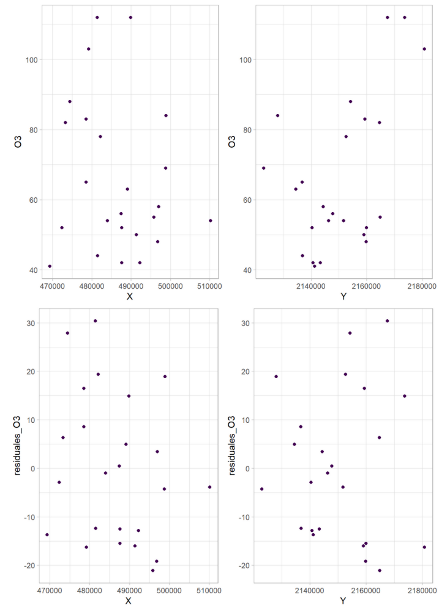

Figura 4.2: Diagramas de dispersión de la concentración de ozono en muestras de aire en Ciudad de México a lo largo de cada coordenada espacial. Panel superior: datos observados. Panel inferior: residuales del modelo mostrado en la Tabla 4.1

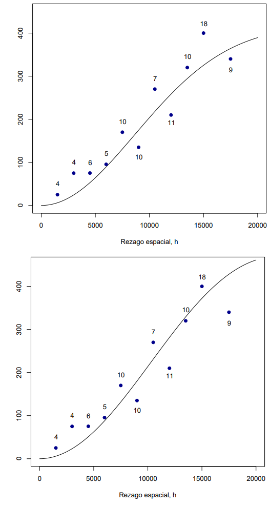

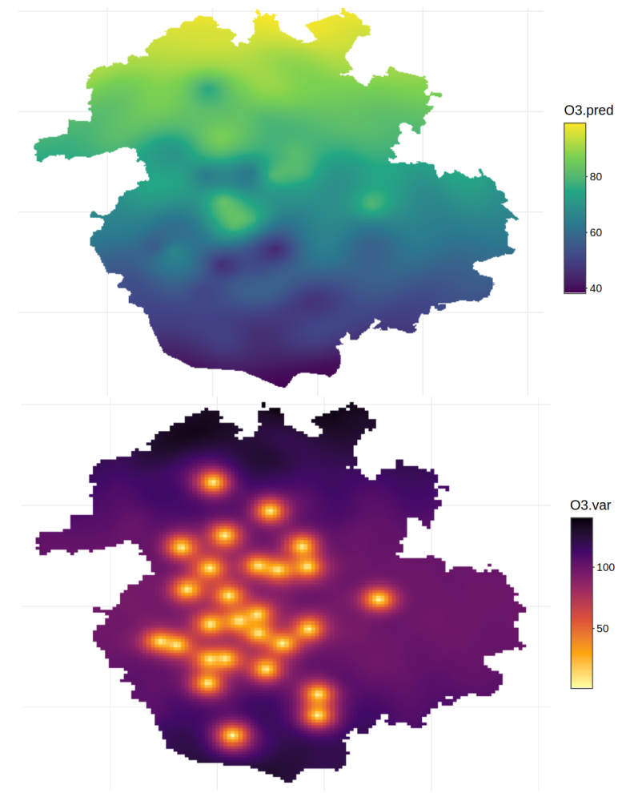

### 9.4.1 Suponga que $Z(s)$ es una función aleatoria estacionaria de segundo orden que representa la precipitación en los cuatro bordes de un trapecio recto. Las realizaciones registradas del fenómeno en estas cuatro ubicaciones son $z_1(0, 0) = 15$; $z_2(100, 0) = 16$; $z_3(0, 50) = 16$ y $z_4(70, 50) = 15$. El modelo de autocorrelación del fenómeno es exponencial con silla 4 y rango 100 m. Encuentre:

1. La predicción con su respectiva varianza de error de predicción, esto es, la varianza del kriging simple para la ubicación $Z(75, 25)$ si la media es conocida e igual a 15,7. Use para sus cálculos la función de covarianza.
2. Si la media es desconocida, pero constante. Use para sus cálculos la función de covarianza.
3. Si la media es desconocida, pero constante. Use para sus cálculos la función de semivarianza.
4. Suponga que el proceso es normal multivariado. Calcule el intervalo de confianza del 95 % para la predicción encontrada en cada caso.
5. Interprete y compare tanto los resultados obtenidos como los procedimientos realizados.

### 9.4.2 Suponga que

$$\mathcal{W}(s) = \Psi(Y(s)) \quad s \in D$$

Donde $Y(s)$ es una variable aleatoria con distribución de probabilidad normal y media constante y conocida $\mu_y$. Demuestre que

$$\mathcal{W}^*(s_0) = \Psi(Y^*(s_0)) + \Psi''(\mu_y) \left\{ \frac{\text{Var}[Y(s) - Y^*(s_0)]}{2} \right\}$$

Esto es, el predictor kriging aplicado a una transformación de la variable espacial es sesgado. *Sugerencia: Utilice el desarrollo en series de Taylor.*

### 9.4.3 Encuentre el predictor kriging si la media es constante y conocida y el modelo de covarianza es un modelo efecto pepita.

### 9.4.4 Encuentre el predictor kriging si la media es un polinomio de primer grado e incluye ambas coordenadas, $(x, y)$, y el modelo de covarianza es un modelo efecto pepita.

### 9.4.5 Suponga un campo aleatorio espacial normal multivariado, con observaciones en $n$ ubicaciones y media y covarianza conocidos. Encuentre la esperanza condicional y la respectiva varianza $Z(s_0)$ dado el vector $(Z(s_1), \dots, Z(s_n))$. Compare con las expresiones de predicción y varianza del error de predicción del kriging simple.

### 9.4.6 Para los datos de aquifer

que puede encontrar en https://mpbohorquezc.github.io/SpatFD-Functional-Geostatistics/GeoestadisticaUnivariadaConGeoR.html, genere dos mapas de predicciones.

Para el primer mapa utilice el predictor kriging y para el segundo mapa utilice predicción basada en modelos de regresión en términos de las coordenadas $(x, y) = (\text{Este}, \text{Norte})$, e incluyendo la dependencia espacial a través de la estimación de los parámetros del modelo, vía máxima verosimilitud. Compare el desempeño predictivo del modelo de regresión cuando se usan mínimos cuadrados ordinarios ignorando la dependencia espacial y cuando se usa máxima verosimilitud. Posteriormente, compare el desempeño de la regresión con el kriging.

### 9.4.7 Simule campos aleatorios espaciales bajo el supuesto de normalidad multivariada, para varios tipos de autocovarianza espacial. Grafique los dispersogramas rezagados variando modelos y parámetros. Esto es, en cada caso, grafique $Y(s)$ Vs $Y(s+h)$, para varios valores de $h$. y en cada caso calcule el coeficiente de correlación de Pearson. Analice.

### 9.4.8 Se requiere llevar a cabo predicción espacial para un proceso espacial cuya distribución marginal es lognormal con media conocida. ¿Es posible encontrar un predictor insesgado? Demuestre o refute.

### 9.4.9 Generalice el resultado encontrado en el problema anterior, al caso en el que se transforma la variable usando una transformación Box-Cox.